# False-ring proportion

Konrad Mayer

2025-01-31

# Introduction

Intra annual density fluctuations (iadfs), also referred as false rings are defined as either latewood-like cells in earlywood or earlywood-like cells in latewood (Fritts 1976). Although recent efforts are made to specify the position, extend as well as intensity of iadfs most studies use binary assignments to indicate presence or absence of iadfs (Battipaglia et al. 2016). While frequencies can easily be calculated as the proportion of rings showing an iadf in a specific year several studies suggest the consideration of variing variances, age trends as well as influence of ring size. This package implements all published approaches known by the package author, their usage is shortly explained in this vignette.

# Data

The data used in this vignette is included in the package. You can load the data-sets called `example_rwl` and `example_iadf` by typing:

```r
library("iadf")
data("example_rwl")
data("example_iadf")
```

`example_rwl` is a data frame, similar to the class `rwl` defined by the package `dplR` with series as columns and years as rows, rownames specifying the year. The data shows the ring width with years not covered by the sample marked with `NA`.

|  | BawPN05b | BawPN06a | BawPN06b | BawPN07a | BawPN07b | BawPN08a | BawPN08b |
| --- | --- | --- | --- | --- | --- | --- | --- |
| 1900 | NA | NA | NA | NA | NA | 246 | 226 |
| 1901 | NA | NA | NA | NA | NA | 184 | 156 |
| 1902 | 209 | NA | NA | NA | NA | 208 | 166 |
| 1903 | 265 | NA | 255 | NA | NA | 213 | 178 |
| 1904 | 114 | 113 | 105 | NA | NA | 116 | 90 |
| 1905 | 160 | 141 | 121 | NA | NA | 132 | 115 |
| 1906 | 170 | 124 | 248 | NA | NA | 158 | 156 |
| 1907 | 112 | 75 | 188 | 188 | NA | 123 | 71 |
| 1908 | 93 | 73 | 115 | 179 | 178 | 91 | 50 |
| 1909 | 135 | 80 | 116 | 225 | 215 | 127 | 89 |
| 1910 | 151 | 117 | 137 | 290 | 219 | 145 | 120 |

`example_iadf` has the same dimensions as `example_rwl`, just showing binary assignments of iadfs instead of ring width.

|  | BawPN05b | BawPN06a | BawPN06b | BawPN07a | BawPN07b | BawPN08a | BawPN08b |
| --- | --- | --- | --- | --- | --- | --- | --- |
| 1900 | NA | NA | NA | NA | NA | 1 | 1 |
| 1901 | NA | NA | NA | NA | NA | 1 | 1 |
| 1902 | 1 | NA | NA | NA | NA | 0 | 1 |
| 1903 | 0 | NA | 1 | NA | NA | 0 | 0 |
| 1904 | 1 | 1 | 0 | NA | NA | 0 | 0 |
| 1905 | 1 | 1 | 1 | NA | NA | 1 | 0 |
| 1906 | 0 | 1 | 1 | NA | NA | 1 | 0 |
| 1907 | 0 | 0 | 0 | 1 | NA | 1 | 0 |
| 1908 | 0 | 0 | 0 | 1 | 1 | 0 | 0 |
| 1909 | 0 | 0 | 0 | 1 | 1 | 1 | 0 |
| 1910 | 1 | 1 | 1 | 1 | 1 | 1 | 0 |

# False-ring proportions

## Naive approach

The proportion of rings showing an iadf can easily be calculated using base R:

```r
rowMeans(example_iadf, na.rm = TRUE)
```

However, there’s also a function in the package `iadf` to calculate the false ring proportion with data frame output consistent to the other package functions and improved warning messages.

```r
results_frp <- frp(example_iadf)
```

Please mention that this function is somehow slower than using `rowMeans()`, so consider using the base R code whenever computation speed is critical.

## Consideration of sample size

As the variance of time series is dependent on sample size the variance can be adjusted according to Osborn (1997), using the function `afrp()`:

```r
results_afrp <- afrp(example_iadf)
```

## Consideration of age trend

As other tree ring parameters, also IADF occurrence shows an age trend. Novak (2013) suggested a detrending procedure to reduce this bias.

First the iadf frequency per cambial age needs to be calculated:

```r
frq <- novak_freq(example_iadf)
```

Then we try to model the influence of age on iadf frequency using a Weibull function as suggested by Novak (2013), limiting the data pairs used to cambial ages representing at least 15 years:

```r
mdl <- novak_weibull(frq, 15)
```

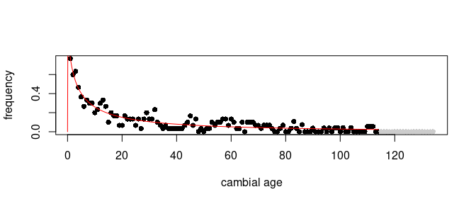

If you encounter an error its likely due to insufficient starting values for the curve fitting function (which can be found using `novak_weibull_find_start()` and will be discussed for `campelo_chapman_find_start()`in the next section).

Next we hand the model and the original data to the function `novak_index()` to calculate the iadf proportion with age trend removed:

```r
results_novak <- novak_index(example_iadf, mdl)
```

## Consideration of the influence of ring width

Campelo (2014) states that beneath ring age also ring width influences iadf formation and introduced another standardization approach.

The workflow implemented in `iadf` is almost the same as for the approach above. Fist we calculate frequencies per ring width class using both data sets:

```r
frq <- campelo_freq(example_iadf, example_rwl)
```

Then we fit a chapman function to our frequencies:

```r
mdl <- campelo_chapman(frq)
```

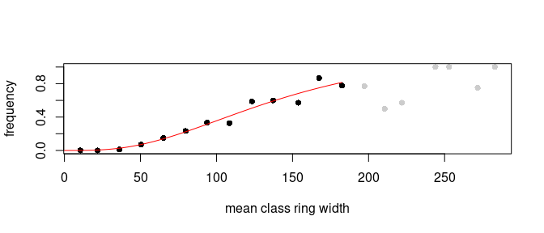

In case the function throws an error it’s likely due to insufficient starting values. These can be found interactively with `campelo_chapman_find_start()` and then used in `campelo_chapman()`:

```r
st <- campelo_chapman_find_start(frq)
mdl <- campelo_chapman(frq, start = st)
```

Next the index is calculated using both data sets and the model:

```r
results_campelo <- campelo_index(example_iadf, example_rwl, mdl)
```

# Comparison of the approaches

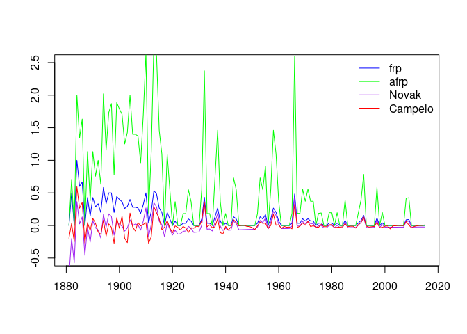

```r
plot(NULL, xlim = range(as.numeric(rownames(example_iadf))),
     ylim = c(-0.5, 2.5), xlab = '', ylab = '')
lines(results_frp, col = 'blue')
lines(results_afrp, col = 'green')
lines(results_novak, col = 'purple')
lines(results_campelo[ , c(1,3)], col = 'red')
legend('topright', col = c('blue', 'green', 'purple', 'red'),
       legend = c('frp', 'afrp', 'Novak', 'Campelo'), bty = 'n', lty = 1)
```

# References

Battipaglia, Giovanna, Filipe Campelo, Joana Vieira, Michael Grabner, Veronica De Micco, Cristina Nabais, Paolo Cherubini, et al. 2016. “Structure and Function of IntraAnnual Density Fluctuations: Mind the Gaps.” *Frontiers in Plant Science* 7 (May). https://doi.org/10.3389/fpls.2016.00595.

Campelo, Filipe, Joana Vieira, Giovanna Battipaglia, Martin de Luis, Cristina Nabais, Helena Freitas, and Paolo Cherubini. 2014. “Which Matters Most for the Formation of Intra-Annual Density Fluctuations in Pinus Pinaster: Age or Size?” *Trees* 29 (1): 237–45. https://doi.org/10.1007/s00468-014-1108-9.

Fritts, H. 1976. *Tree Rings and Climate*. Academic Press.

Novak, Klemen, Katarina Čufar, Martin de Luis, Miguel Angel Saz Sánchez, and Josep Raventós. 2013. “Age, Climate and Intra-Annual Density Fluctuations in Pinus Halepensis in Spain.” *IAWA Journal* 34 (4): 459–74. https://doi.org/10.1163/22941932-00000037.

Osborn, T. J., K. R. Briffa, and P. D. Jones. 1997. “Adjusting variance for sample-size in tree-ring chronologies and other regional-mean time-series.” *Dendrochronologia* 15: 89–99.